# STAT 420: Homework 6

Fall 2016, Unger

Due: Monday, October 24 by 11:50 PM CT

# Assignment

## Exercise 1 (EPA Emissions Data)

For this exercise we will use the data stored in `epa2015.csv`. It contains detailed descriptions of 4,411 vehicles manufactured in 2015 used for fuel economy testing [as performed by the Environment Protection Agency](https://www3.epa.gov/otaq/tcldata.htm). The variables in the dataset are:

- `Make` - manufacturer
- `Model` - model of vehicle
- `ID` - manufacturer defined vehicle identification number within EPA’s computer system (not a VIN number)
- `disp` - cubic inch displacement of test vehicle
- `type` - car, truck, or both (for vehicles that meet specifications of both car and truck, like smaller SUVs or crossovers)
- `horse` - rated horsepower, in foot-pounds per second
- `cyl` - number of cylinders
- `lockup` - vehicle has transmission lockup; N or Y
- `drive` - drivetrain system code
  - A = All wheel drive
  - F = Front wheel drive
  - P = Part-time 4-wheel drive
  - R = Rear wheel drive
  - 4 = 4-wheel drive
- `weight` - test weight, in pounds
- `axleratio` - axle ratio
- `nvratio` - n/v ratio (engine speed versus vehicle speed at 50 mph)
- `THC` - total hydrocarbons, in grams per mile (g/mi)
- `CO` - Carbon monoxide (a regulated pollutant), in g/mi
- `CO2` - Carbon dioxide (the primary byproduct of all fossil fuel combustion), in g/mi
- `mpg` - fuel economy, in miles per gallon

We will attempt to model `CO2` using both `horse` and `type`. In practice we would use many more predictors, but limiting ourselves to these two, one numeric and one factor, will allow us to create a number of plots.

**(a)** Load the data, and check its structure using `str()`. Verify that `type` is a factor, if not, coerce it to be a factor.

```r
epa2015 <- read.csv("~/Downloads/epa2015.csv", header=TRUE)

str(epa2015)
```

```
## 'data.frame':    4411 obs. of  16 variables:
##  $ Make     : Factor w/ 30 levels "aston martin",..: 1 1 1 1 1 1 1 1 1 1 ...
##  $ Model    : Factor w/ 635 levels "1500 2WD","1500 4X4",..: 189 189 479 479 579 579 582 582 583 583 ...
##  $ ID       : Factor w/ 872 levels "08-UF2H","0C00007",..: 82 82 180 180 149 149 136 136 148 148 ...
##  $ disp     : num  5.9 5.9 6 6 6 6 4.7 4.7 4.7 4.7 ...
##  $ type     : Factor w/ 3 levels "Both","Car","Truck": 2 2 2 2 2 2 2 2 2 2 ...
##  $ horse    : int  510 510 552 552 565 565 420 420 430 430 ...
##  $ cyl      : int  12 12 12 12 12 12 8 8 8 8 ...
##  $ lockup   : Factor w/ 2 levels "N","Y": 2 2 2 2 2 2 1 1 2 2 ...
##  $ drive    : Factor w/ 5 levels "4","A","F","P",..: 5 5 5 5 5 5 5 5 5 5 ...
##  $ weight   : int  4500 4500 4750 4750 4250 4250 4000 4000 4000 4000 ...
##  $ axleratio: num  3.46 3.46 2.73 2.73 3.73 3.73 3.91 3.91 4.18 4.18 ...
##  $ nvratio  : num  31 31 22.4 22.4 33.6 33.6 38.6 38.6 36.2 36.2 ...
##  $ THC      : num  0.0251 0.0022 0.0269 0.0008 0.0248 ...
##  $ CO       : num  0.12 0.0118 0.5 0.06 0.61 ...
##  $ CO2      : num  550 344 512 297 603 ...
##  $ mpg      : num  16.1 25.8 17.3 29.9 14.8 25.3 16 26.5 16.7 28.8 ...
```

```r
is.factor(epa2015$type)
```

```
## [1] TRUE
```

**(b)** Make a scatterplot of `CO2` versus `horse`. Use a different color point for each vehicle `type`. Which color is which `type`?

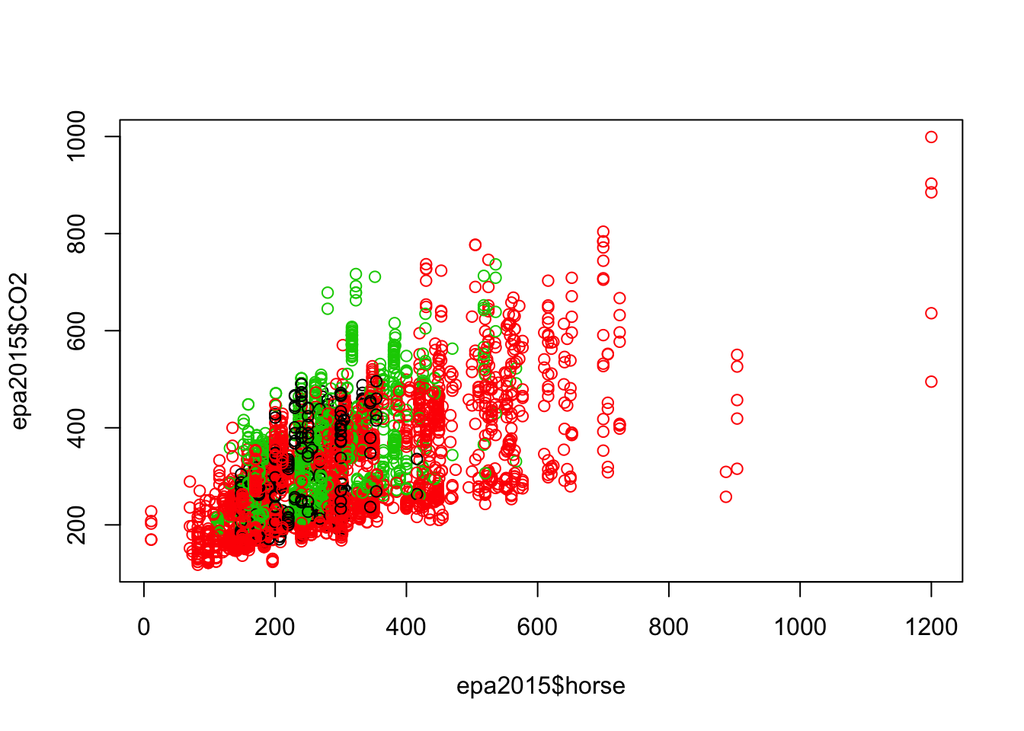

```r
epa2015 <- read.csv("~/Downloads/epa2015.csv", header=TRUE)
plot(epa2015$CO2 ~ epa2015$horse, data = epa2015, col = epa2015$type)
```

```r
#From this plot I can see that red is for type car, black is for both, and green is for the trucks.
```

**(c)** Fit a SLR model with `CO2` as the response and only `horse` as the predictor. Recreate your plot and add the fitted regression line. Comment on how well this line models the data. Give an estimate for the average change in `CO2` for a one foot-pound per second increase in `horse` for a vehicle of type `truck`. Give a 95% prediction interval using this model for the `CO2` of a Subaru Impreza Wagon which is a vehicle with 148 horsepower and is considered type `Both`. (Interestingly, the dataset gives the wrong drivetrain for most Subarus in this dataset, as they are almost all listed as `F`, when they are in fact All-Wheel-Drive.)

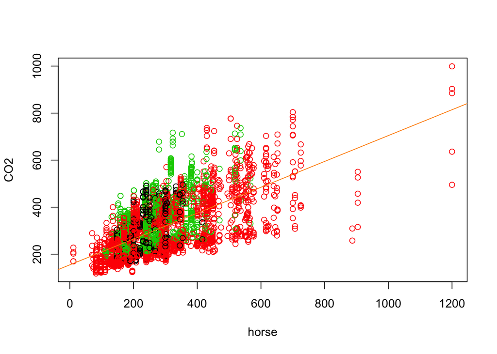

```r
epa2015 <- read.csv("~/Downloads/epa2015.csv", header=TRUE)

##Fit a SLR model with `CO2` as the response and only `horse` as the predictor. Recreate your plot and add the fitted regression line. Comment on how well this line models the data.
CO2_slr = lm(CO2 ~ horse, data=epa2015)
plot(CO2 ~ horse, data = epa2015, col = type)
abline(CO2_slr, col = "darkorange")
```

```r
#This line seems to model the data fairly well.
```

```r
##Give an estimate for the average change in `CO2` for a one foot-pound per second increase in `horse` for a vehicle of type `truck`.
coef(CO2_slr)
```

```
## (Intercept)       horse
## 154.7178499   0.5498996
```

```r
##Give a 95% prediction interval using this model for the `CO2` of a Subaru Impreza Wagon which is a vehicle with 148 horsepower and is considered type `Both`.
```

```r
subaru = data.frame(horse=148,type="Both")
predict(CO2_slr, subaru, interval = "prediction", level = 0.95)
```

```
##       fit      lwr      upr
## 1 236.103 61.35505 410.8509
```

**(d)** Fit an additive multiple regression model with `CO2` as the response and `horse` and `type` as the predictors. Recreate your plot and add the fitted regression “lines” with the same colors as their respective points. Comment on how well these lines models the data. Give an estimate for the average change in `CO2` for a one foot-pound per second increase in `horse` for a vehicle of type `truck`. Give a 95% prediction interval using this model for the `CO2` of a Subaru Impreza Wagon which is a vehicle with 148 horsepower and is considered type `Both`.

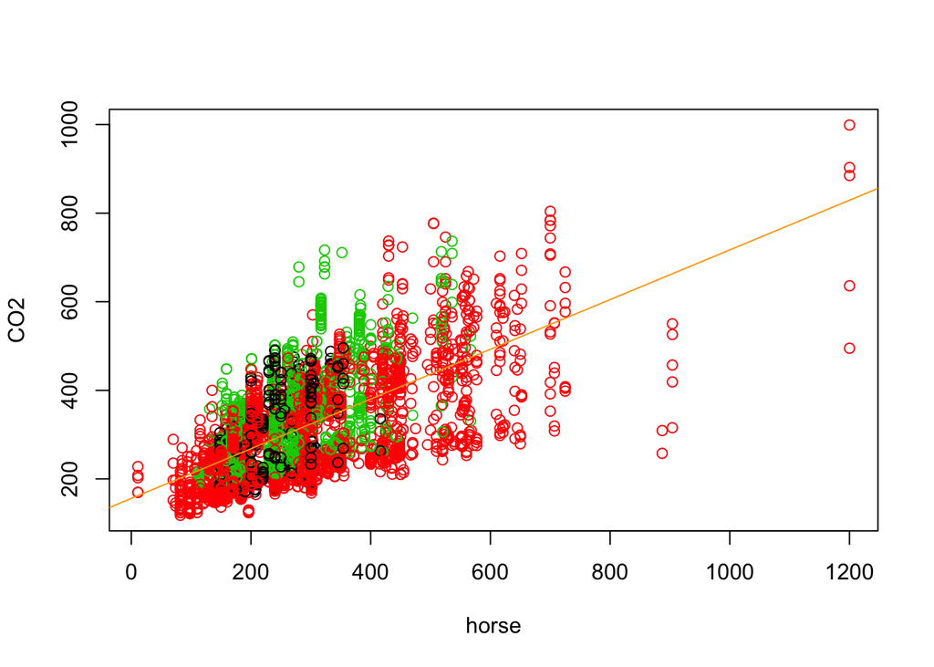

```r
##Fit an additive multiple regression model with `CO2` as the response and `horse` and `type` as the predictors. Recreate your plot and add the fitted regression "lines" with the same colors as their
CO2_mlr = lm(CO2 ~ horse + type, data = epa2015)
plot(CO2 ~ horse, data = epa2015, col = type)
abline(CO2_mlr, lwr = 3, col = "orange")
```

```r
#Looks like a good model.
```

```r
##Give an estimate for the average change in `CO2` for a one foot-pound per second increase in `horse` for a vehicle of type `truck`.
coef(CO2_mlr)[2]
```

```
##     horse
## 0.5611008
```

```r
##Give a 95% prediction interval using this model for the `CO2` of a Subaru Impreza Wagon which is a vehicle with 148 horsepower and is considered type `Both`
subaru = data.frame(horse=148,type="Both")
predict(CO2_mlr, subaru, interval = "prediction", level = 0.95)
```

```
##        fit      lwr      upr
## 1 239.0251 71.67975 406.3704
```

**(e)** Fit an interaction multiple regression model with `CO2` as the response and `horse` and `type` as the predictors. Recreate your plot and add the fitted regression “lines” with the same colors as their respective points. Comment on how well these lines models the data. Give an estimate for the average change in `CO2` for a one foot-pound per second increase in `horse` for a vehicle of type `truck`. Give a 95% prediction interval using this model for the `CO2` of a Subaru Impreza Wagon which is a vehicle with 148 horsepower and is considered type `Both`.

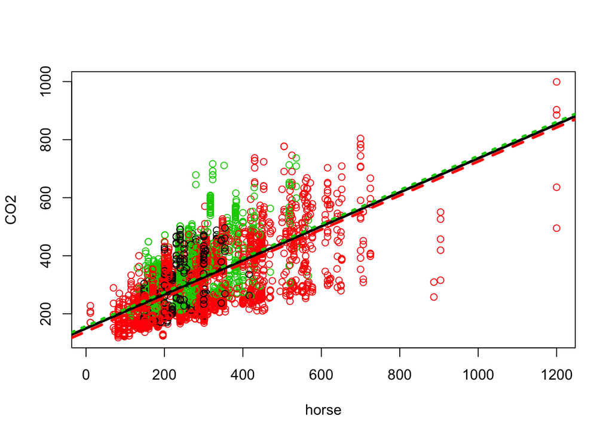

```r
##Fit an interaction multiple regression model with `CO2` as the response and `horse` and `type` as the predictors. Recreate your plot and add the fitted regression "lines" with the same colors as their respective points.
CO2_int = lm(CO2 ~ horse*type, data=epa2015)
type_both = coef(CO2_int)[1]
type_car = coef(CO2_int)[1] + coef(CO2_int)[3]
type_truck = coef(CO2_int)[1] + coef(CO2_int)[4]
type_slope = coef(CO2_int)[2]

plot(CO2 ~ horse, data = epa2015, col = type)
abline(type_both, type_slope, col = 1, lty = 1, lwd = 3)
abline(type_car, type_slope, col = 2, lty = 2, lwd = 3)
abline(type_truck, type_slope, col = 3, lty = 3, lwd = 3)
```

```r
#These lines look like good fits
```

```r
##Give an estimate for the average change in `CO2` for a one foot-pound per second increase in `horse` for a vehicle of type `truck`.
est = coef(CO2_int)[2] + coef(CO2_int)[6]
est
```

```
##     horse
## 0.7013883
```

```r
##Give a 95% prediction interval using this model for the `CO2` of a Subaru Impreza Wagon which is a vehicle with 148 horsepower and is considered type `Both`. (Same as above problems)
subaru = data.frame(horse=148,type="Both")
predict(CO2_int,subaru,interval = "prediction", level=0.95)
```

```
##        fit      lwr      upr
## 1 236.6339 69.29175 403.9761
```

**(f)** You will perform $F$-tests later in the exercise, but for now, based solely on the three previous plots, which model is preferred: SLR, additive, or interaction?

```r
##The interaction model is what is preffered. This is because it better models the amount in g of co2 of the cars by looking at their horsepower and their type together.
```

**(g)** Use an ANOVA $F$-test to compare the SLR and additive models. Based on this test and a significance level of $\alpha = 0.01$, which model is preferred?

```r
anova(CO2_slr, CO2_mlr)
```

```
## Analysis of Variance Table
##
## Model 1: CO2 ~ horse
## Model 2: CO2 ~ horse + type
##   Res.Df      RSS Df Sum of Sq      F    Pr(>F)
## 1   4409 35012540
## 2   4407 32054899  2   2957641 203.31 < 2.2e-16 ***
## ---
## Signif. codes:  0 '***' 0.001 '**' 0.01 '*' 0.05 '.' 0.1 ' ' 1
```

```r
##Based on the F-stat is 203.31 and the very low p-value (< 2.2e-16) and the significance level of 0.01 we reject the null hypothesis and choose the additive model.
```

**(h)** Use an ANOVA $F$-test to compare the additive and interaction models. Based on this test and a significance level of $\alpha = 0.01$, which model is preferred?

```r
anova(CO2_mlr,CO2_int)
```

```
## Analysis of Variance Table
##
## Model 1: CO2 ~ horse + type
## Model 2: CO2 ~ horse * type
##   Res.Df      RSS Df Sum of Sq      F    Pr(>F)
## 1   4407 32054899
## 2   4405 31894278  2    160621 11.092 1.567e-05 ***
## ---
## Signif. codes:  0 '***' 0.001 '**' 0.01 '*' 0.05 '.' 0.1 ' ' 1
```

```r
##Based on the F-stat of 11.092 and low p-value of 1.567e-05 and the significance level of 0.01 we reject the null, and choose interaction.
```